IE 7300: Statistical learning for Engineering

# **Homework 5**

Gauri Damle

2064683093

damle.g@northeastern.edu

Percentage of Effort Contributed by Student :

Signature of Student : Gauri Damle

Submission Date: 18th October 2022

# **Importing Modules**

```python
!pip install dtreeviz
```

```python
!pip install scikit-plot
```

```python
!pip install graphviz
```

```python
#import the required libraries

import pandas as pd
import matplotlib.pyplot as plt
%matplotlib inline
import numpy as np
import seaborn as sns
import random
from sklearn.utils import shuffle
import statsmodels.api as sm
import itertools
import time
from mpl_toolkits import mplot3d


#Preprocessing methods
from sklearn.preprocessing import StandardScaler
from sklearn.preprocessing import MinMaxScaler
from sklearn.preprocessing import OneHotEncoder
from sklearn.preprocessing import LabelEncoder

#Split the training and test dataset
from sklearn.model_selection import train_test_split



### Visualize tree
from sklearn import tree
from sklearn.tree import DecisionTreeClassifier
from sklearn.tree import DecisionTreeRegressor
from sklearn.tree import export_text


### performance matrix
from sklearn.metrics import mean_squared_error, accuracy_score, confusion_matrix, r2_score
from sklearn.metrics import plot_confusion_matrix
import scikitplot as skplt
```

```python
from google.colab import drive
drive.mount('/content/drive')
```

```python
!jupyter nbconvert --to html /content/drive/MyDrive/SemesterThree/Stats7300/Assignment5/Assignment5.ipynb
```

```
[NbConvertApp] Converting notebook /content/drive/MyDrive/SemesterThree/Stats7300/Assignment5/Assignment5.ipynb to html
[NbConvertApp] Writing 1109225 bytes to /content/drive/MyDrive/SemesterThree/Stats7300/Assignment5/Assignment5.html
```

# **Decision Trees**

A Decision Tree is a supervised algorithm used in machine learning. It is using a binary tree graph (each node has two children) to assign for each data sample a target value. The target values are presented in the tree leaves. To reach to the leaf, the sample is propagated through nodes, starting at the root node. In each node a decision is made, to which descendant node it should go. A decision is made based on the selected sample’s feature. Decision Tree learning is a process of finding the optimal rules in each internal tree node according to the selected metric.

The decision trees can be divided, with respect to the target values, into:

1. **Classification** trees used to classify samples, assign to a limited set of values - classes. In scikit-learn it is DecisionTreeClassifier.
2. **Regression** trees used to assign samples into numerical values within the range. In scikit-learn it is DecisionTreeRegressor.

# **Custom Regression Model**

```python
class Node():
    def __init__(self, feature_index=None, threshold=None, left=None, right=None, var_red=None, value=None):
        ''' constructor '''

        # for decision node
        self.feature_index = feature_index
        self.threshold = threshold
        self.left = left
        self.right = right
        self.var_red = var_red

        # for leaf node
        self.value = value
```

```python
class custom_DecisionTreeRegressor():
    def __init__(self, min_samples_split=2, max_depth=2):
        ''' constructor '''

        # initialize the root of the tree
        self.root = None

        # stopping conditions
        self.min_samples_split = min_samples_split
        self.max_depth = max_depth

    def build_tree(self, dataset, curr_depth=0):
        ''' recursive function to build the tree '''

        X, Y = dataset[:,:-1], dataset[:,-1]
        num_samples, num_features = np.shape(X)
        best_split = {}
        # split until stopping conditions are met
        if num_samples>=self.min_samples_split and curr_depth<=self.max_depth:
            # find the best split
            best_split = self.get_best_split(dataset, num_samples, num_features)
            # check if information gain is positive
            if best_split["var_red"]>0:
                # recur left
                left_subtree = self.build_tree(best_split["dataset_left"], curr_depth+1)
                # recur right
                right_subtree = self.build_tree(best_split["dataset_right"], curr_depth+1)
                # return decision node
                return Node(best_split["feature_index"], best_split["threshold"],
                            left_subtree, right_subtree, best_split["var_red"])

        # compute leaf node
        leaf_value = self.calculate_leaf_value(Y)
        # return leaf node
        return Node(value=leaf_value)

    def get_best_split(self, dataset, num_samples, num_features):
        ''' function to find the best split '''

        # dictionary to store the best split
        best_split = {}
        max_var_red = -float("inf")
        # loop over all the features
        for feature_index in range(num_features):
            feature_values = dataset[:, feature_index]
            possible_thresholds = np.unique(feature_values)
            # loop over all the feature values present in the data
            for threshold in possible_thresholds:
                # get current split
                dataset_left, dataset_right = self.split(dataset, feature_index, threshold)
                # check if childs are not null
                if len(dataset_left)>0 and len(dataset_right)>0:
                    y, left_y, right_y = dataset[:, -1], dataset_left[:, -1], dataset_right[:, -1]
                    # compute information gain
                    curr_var_red = self.variance_reduction(y, left_y, right_y)
                    # update the best split if needed
                    if curr_var_red>max_var_red:
                        best_split["feature_index"] = feature_index
                        best_split["threshold"] = threshold
                        best_split["dataset_left"] = dataset_left
                        best_split["dataset_right"] = dataset_right
                        best_split["var_red"] = curr_var_red
                        max_var_red = curr_var_red

        # return best split
        return best_split

    def split(self, dataset, feature_index, threshold):
        ''' function to split the data '''

        dataset_left = np.array([row for row in dataset if row[feature_index]<=threshold])
        dataset_right = np.array([row for row in dataset if row[feature_index]>threshold])
        return dataset_left, dataset_right

    def variance_reduction(self, parent, l_child, r_child):
        ''' function to compute variance reduction '''

        weight_l = len(l_child) / len(parent)
        weight_r = len(r_child) / len(parent)
        reduction = np.var(parent) - (weight_l * np.var(l_child) + weight_r * np.var(r_child))
        return reduction

    def calculate_leaf_value(self, Y):
        ''' function to compute leaf node '''

        val = np.mean(Y)
        return val

    def print_tree(self, tree=None, indent=" "):
        ''' function to print the tree '''

        if not tree:
            tree = self.root

        if tree.value is not None:
            print(tree.value)

        else:
            print("X_"+str(tree.feature_index), "<=", tree.threshold, "?", tree.var_red)
            print("%sleft:" % (indent), end="")
            self.print_tree(tree.left, indent + indent)
            print("%sright:" % (indent), end="")
            self.print_tree(tree.right, indent + indent)

    def fit(self, X, Y):
        ''' function to train the tree '''

        dataset = np.concatenate((X, Y), axis=1)
        self.root = self.build_tree(dataset)

    def make_prediction(self, x, tree):
        ''' function to predict new dataset '''

        if tree.value!=None: return tree.value
        feature_val = x[tree.feature_index]
        if feature_val<=tree.threshold:
            return self.make_prediction(x, tree.left)
        else:
            return self.make_prediction(x, tree.right)

    def predict(self, X):
        ''' function to predict a single data point '''

        preditions = [self.make_prediction(x, self.root) for x in X]
        return preditions
```

# **Custom Classifier model**

```python
class Node_classification():
    def __init__(self, feature_index=None, threshold=None, left=None, right=None, info_gain=None, value=None):
        ''' constructor '''

        # for decision node
        self.feature_index = feature_index
        self.threshold = threshold
        self.left = left
        self.right = right
        self.info_gain = info_gain

        # for leaf node
        self.value = value
```

```python
class custom_DecisionTreeClassifier():
    def __init__(self, min_samples_split=2, max_depth=2):
        ''' constructor '''

        # initialize the root of the tree
        self.root = None

        # stopping conditions
        self.min_samples_split = min_samples_split
        self.max_depth = max_depth

    def build_tree(self, dataset, curr_depth=0):
        ''' recursive function to build the tree '''

        X, Y = dataset[:,:-1], dataset[:,-1]
        num_samples, num_features = np.shape(X)

        # split until stopping conditions are met
        if num_samples>=self.min_samples_split and curr_depth<=self.max_depth:
            # find the best split
            best_split = self.get_best_split(dataset, num_samples, num_features)
            # check if information gain is positive
            if best_split["info_gain"]>0:
                # recur left
                left_subtree = self.build_tree(best_split["dataset_left"], curr_depth+1)
                # recur right
                right_subtree = self.build_tree(best_split["dataset_right"], curr_depth+1)
                # return decision node
                return Node_classification(best_split["feature_index"], best_split["threshold"],
                            left_subtree, right_subtree, best_split["info_gain"])

        # compute leaf node
        leaf_value = self.calculate_leaf_value(Y)
        # return leaf node
        return Node_classification(value=leaf_value)

    def get_best_split(self, dataset, num_samples, num_features):
        ''' function to find the best split '''

        # dictionary to store the best split
        best_split = {}
        max_info_gain = -float("inf")

        # loop over all the features
        for feature_index in range(num_features):
            feature_values = dataset[:, feature_index]
            possible_thresholds = np.unique(feature_values)
            # loop over all the feature values present in the data
            for threshold in possible_thresholds:
                # get current split
                dataset_left, dataset_right = self.split(dataset, feature_index, threshold)
                # check if childs are not null
                if len(dataset_left)>0 and len(dataset_right)>0:
                    y, left_y, right_y = dataset[:, -1], dataset_left[:, -1], dataset_right[:, -1]
                    # compute information gain
                    curr_info_gain = self.information_gain(y, left_y, right_y, "gini")
                    # update the best split if needed
                    if curr_info_gain>max_info_gain:
                        best_split["feature_index"] = feature_index
                        best_split["threshold"] = threshold
                        best_split["dataset_left"] = dataset_left
                        best_split["dataset_right"] = dataset_right
                        best_split["info_gain"] = curr_info_gain
                        max_info_gain = curr_info_gain

        # return best split
        return best_split

    def split(self, dataset, feature_index, threshold):
        ''' function to split the data '''

        dataset_left = np.array([row for row in dataset if row[feature_index]<=threshold])
        dataset_right = np.array([row for row in dataset if row[feature_index]>threshold])
        return dataset_left, dataset_right

    def information_gain(self, parent, l_child, r_child, mode="entropy"):
        ''' function to compute information gain '''

        weight_l = len(l_child) / len(parent)
        weight_r = len(r_child) / len(parent)
        if mode=="gini":
            gain = self.gini_index(parent) - (weight_l*self.gini_index(l_child) + weight_r*self.gini_index(r_child))
        else:
            gain = self.entropy(parent) - (weight_l*self.entropy(l_child) + weight_r*self.entropy(r_child))
        return gain

    def entropy(self, y):
        ''' function to compute entropy '''

        class_labels = np.unique(y)
        entropy = 0
        for cls in class_labels:
            p_cls = len(y[y == cls]) / len(y)
            entropy += -p_cls * np.log2(p_cls)
        return entropy

    def gini_index(self, y):
        ''' function to compute gini index '''

        class_labels = np.unique(y)
        gini = 0
        for cls in class_labels:
            p_cls = len(y[y == cls]) / len(y)
            gini += p_cls**2
        return 1 - gini

    def calculate_leaf_value(self, Y):
        ''' function to compute leaf node '''

        Y = list(Y)
        return max(Y, key=Y.count)

    def print_tree(self, tree=None, indent=" "):
        ''' function to print the tree '''

        if not tree:
            tree = self.root

        if tree.value is not None:
            print(tree.value)

        else:
            print("X_"+str(tree.feature_index), "<=", tree.threshold, "?", tree.info_gain)
            print("%sleft:" % (indent), end="")
            self.print_tree(tree.left, indent + indent)
            print("%sright:" % (indent), end="")
            self.print_tree(tree.right, indent + indent)

    def fit(self, X, Y):
        ''' function to train the tree '''

        dataset = np.concatenate((X, Y), axis=1)
        self.root = self.build_tree(dataset)

    def predict(self, X):
        ''' function to predict new dataset '''

        preditions = [self.make_prediction(x, self.root) for x in X]
        return preditions

    def make_prediction(self, x, tree):
        ''' function to predict a single data point '''

        if tree.value!=None: return tree.value
        feature_val = x[tree.feature_index]
        if feature_val<=tree.threshold:
            return self.make_prediction(x, tree.left)
        else:
            return self.make_prediction(x, tree.right)
```

# **Question1**

1. Create a custom decision tree model using the house pricing dataset

a) Split the dataset into training and test dataset 80:20

b) Create a decision tree model for classification and prediction in python class format. Fit the model using training dataset. Show the model and provide proper interpretation on each node split.

c) Predict the house prices using the test dataset, and provide the performance metrics. Compare your output with homework 3 output (Only performance metrics are fine. Do not need to repeat the code).

d) Do you see any overfitting? How to overcome the overfitting issues?

## Input Data

```python
df1 = pd.read_csv('/content/drive/MyDrive/SemesterThree/Stats7300/Assignment3/houseprices.csv')
```

```python
df1.shape
```

```
(128, 8)
```

```python
df1.info()

# No null data
# The datatype of all features is integer except for the last two columns
  # - Brick
  # - Neighborhood
```

```
<class 'pandas.core.frame.DataFrame'>
RangeIndex: 128 entries, 0 to 127
Data columns (total 8 columns):
 #   Column        Non-Null Count  Dtype
---  ------        --------------  -----
 0   Home          128 non-null    int64
 1   Price         128 non-null    int64
 2   SqFt          128 non-null    int64
 3   Bedrooms      128 non-null    int64
 4   Bathrooms     128 non-null    int64
 5   Offers        128 non-null    int64
 6   Brick         128 non-null    object
 7   Neighborhood  128 non-null    object
dtypes: int64(6), object(2)
memory usage: 8.1+ KB
```

## Idea/Intuition

```python
df1["Price"].min()
```

```
69100
```

```python
df1["Price"].max()
```

```
211200
```

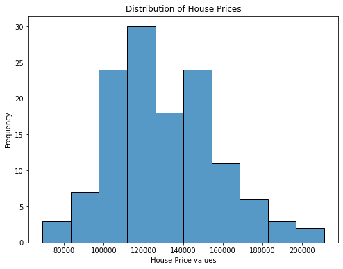

```python
plt.figure(figsize=(8,6))
sns.histplot(df1["Price"])
plt.title("Distribution of House Prices")
plt.ylabel("Frequency")
plt.xlabel("House Price values")
plt.show()
```

As per the graph it is clear that the sample prices fall into numerical values within the range 69100 to 211200

This Regression tree is used to fit the model instead of going for classification.

## Converting text into columns

#### Brick and Neighborhood are categorical variables of object data type need to be converted to numerical values using techniques like

- LableEncoding
- OneHotEncoding
- Mapping function

```python
df1['Brick'].value_counts()
```

```
No     86
Yes    42
Name: Brick, dtype: int64
```

```python
df1['Brick'] = df1['Brick'].map({"No":0, "Yes":1})
```

```python
df1['Neighborhood'].value_counts()
```

```
East     45
North    44
West     39
Name: Neighborhood, dtype: int64
```

```python
directions = {'East':0, 'North':1, 'West':2}
df1['Neighborhood'] = df1['Neighborhood'].map(directions)
```

```python
df1.describe()
```

|  | Home | Price | SqFt | Bedrooms | Bathrooms | Offers | Brick | Neighborhood |
| --- | --- | --- | --- | --- | --- | --- | --- | --- |
| count | 128.000000 | 128.000000 | 128.000000 | 128.000000 | 128.000000 | 128.000000 | 128.000000 | 128.000000 |
| mean | 64.500000 | 130427.343750 | 2000.937500 | 3.023438 | 2.445312 | 2.578125 | 0.328125 | 0.953125 |
| std | 37.094474 | 26868.770371 | 211.572431 | 0.725951 | 0.514492 | 1.069324 | 0.471376 | 0.811913 |
| min | 1.000000 | 69100.000000 | 1450.000000 | 2.000000 | 2.000000 | 1.000000 | 0.000000 | 0.000000 |
| 25% | 32.750000 | 111325.000000 | 1880.000000 | 3.000000 | 2.000000 | 2.000000 | 0.000000 | 0.000000 |
| 50% | 64.500000 | 125950.000000 | 2000.000000 | 3.000000 | 2.000000 | 3.000000 | 0.000000 | 1.000000 |
| 75% | 96.250000 | 148250.000000 | 2140.000000 | 3.000000 | 3.000000 | 3.000000 | 1.000000 | 2.000000 |
| max | 128.000000 | 211200.000000 | 2590.000000 | 5.000000 | 4.000000 | 6.000000 | 1.000000 | 2.000000 |

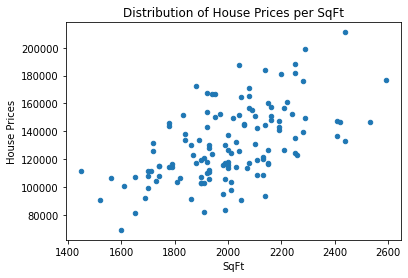

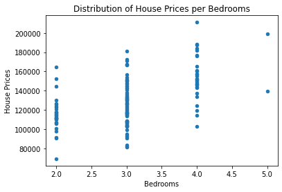

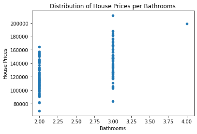

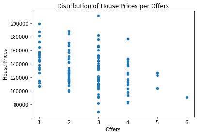

```python
features = ["SqFt",	"Bedrooms",	"Bathrooms",	"Offers"]
for i in range(0,4):
  df1.plot(kind = 'scatter', x=features[i], y='Price')
  plt.xlabel(features[i])
  plt.ylabel('House Prices')
  plt.title('Distribution of House Prices per '+features[i])
  plt.show()
```

## Scaling Dataset

```python
# Scale the dataset
#scaled = ["SqFt",	"Bedrooms",	"Bathrooms",	"Offers"]
#sc = StandardScaler()
#df1[scaled]= sc.fit_transform(df1[scaled])
```

```python
df1.head()
```

|  | Home | Price | SqFt | Bedrooms | Bathrooms | Offers | Brick | Neighborhood |
| --- | --- | --- | --- | --- | --- | --- | --- | --- |
| 0 | 1 | 114300 | 1790 | 2 | 2 | 2 | 0 | 0 |
| 1 | 2 | 114200 | 2030 | 4 | 2 | 3 | 0 | 0 |
| 2 | 3 | 114800 | 1740 | 3 | 2 | 1 | 0 | 0 |
| 3 | 4 | 94700 | 1980 | 3 | 2 | 3 | 0 | 0 |
| 4 | 5 | 119800 | 2130 | 3 | 3 | 3 | 0 | 0 |

## Define features and labels

```python
df1.shape
```

```
(128, 8)
```

```python
# 'Home' column can be dropped as it is nothing but an index
df1 = df1.drop('Home', axis = 1)
```

```python
df1
```

|  | Price | SqFt | Bedrooms | Bathrooms | Offers | Brick | Neighborhood |
| --- | --- | --- | --- | --- | --- | --- | --- |
| 0 | 114300 | 1790 | 2 | 2 | 2 | 0 | 0 |
| 1 | 114200 | 2030 | 4 | 2 | 3 | 0 | 0 |
| 2 | 114800 | 1740 | 3 | 2 | 1 | 0 | 0 |
| 3 | 94700 | 1980 | 3 | 2 | 3 | 0 | 0 |
| 4 | 119800 | 2130 | 3 | 3 | 3 | 0 | 0 |
| ... | ... | ... | ... | ... | ... | ... | ... |
| 123 | 119700 | 1900 | 3 | 3 | 3 | 1 | 0 |
| 124 | 147900 | 2160 | 4 | 3 | 3 | 1 | 0 |
| 125 | 113500 | 2070 | 2 | 2 | 2 | 0 | 1 |
| 126 | 149900 | 2020 | 3 | 3 | 1 | 0 | 2 |
| 127 | 124600 | 2250 | 3 | 3 | 4 | 0 | 1 |

128 rows × 7 columns

```python
#Data contains 6 feature variables and 1 target variable price
# Define features and labels

y = df1.iloc[:,0].values.reshape(-1,1)
```

```python
y.shape
```

```
(128, 1)
```

```python
x = df1.iloc[:,1:].values
```

## a) Split the dataset into training and test dataset 80:20

```python
Xtrain, Xtest, Ytrain, Ytest = train_test_split(x, y, test_size=0.2)
```

```python
Xtrain.shape
```

```
(102, 6)
```

```python
Xtest.shape
```

```
(26, 6)
```

```python
Ytrain.shape
```

```
(102, 1)
```

```python
Ytest.shape
```

```
(26, 1)
```

## b) Create a decision tree model for prediction in python class format. Fit the model using training dataset. Show the model and provide proper interpretation on each node split.

```python
regressor = custom_DecisionTreeRegressor(min_samples_split=2, max_depth=2)
regressor.fit(Xtrain,Ytrain)
regressor.print_tree()
```

```
X_5 <= 1 ? 324762253.6824541
 left:X_0 <= 2010 ? 96335643.7723167
  left:X_4 <= 0 ? 77996094.27609429
    left:104987.87878787878
    right:126511.11111111111
  right:X_5 <= 0 ? 90609222.94843861
    left:137011.76470588235
    right:117300.0
 right:X_4 <= 0 ? 116048052.27600679
  left:X_0 <= 2000 ? 88977785.33635676
    left:136955.55555555556
    right:156016.66666666666
  right:X_0 <= 2150 ? 84118347.2222222
    left:166140.0
    right:190750.0
```

### Interpretation

As per the print tree we are getting feature values at non leaf nodes with conditions.

And leaf nodes corresponding to mean predicted output.

Features are in decreasing order of Importance

[output not shown]

The feature with more information gain values appear at the root level of tree and in descending order of information gain, values other non leaf nodes in tree are followed from top to bottom.

## Visualizing tree

```python
## Using sklearn library to perform regression
regr = DecisionTreeRegressor(max_depth=3)
model = regr.fit(Xtrain, Ytrain)
r = tree.export_text(regr)
print(r)
```

```
|--- feature_5 <= 1.50
|   |--- feature_0 <= 2020.00
|   |   |--- feature_4 <= 0.50
|   |   |   |--- value: [104987.88]
|   |   |--- feature_4 >  0.50
|   |   |   |--- value: [126511.11]
|   |--- feature_0 >  2020.00
|   |   |--- feature_5 <= 0.50
|   |   |   |--- value: [137011.76]
|   |   |--- feature_5 >  0.50
|   |   |   |--- value: [117300.00]
|--- feature_5 >  1.50
|   |--- feature_4 <= 0.50
|   |   |--- feature_0 <= 2010.00
|   |   |   |--- value: [136955.56]
|   |   |--- feature_0 >  2010.00
|   |   |   |--- value: [156016.67]
|   |--- feature_4 >  0.50
|   |   |--- feature_0 <= 2200.00
|   |   |   |--- value: [166140.00]
|   |   |--- feature_0 >  2200.00
|   |   |   |--- value: [190750.00]
```

```python
from dtreeviz.trees import dtreeviz # remember to load the package

viz = dtreeviz(regr, Xtrain, Ytrain,
                target_name="target",
                feature_names=df1.iloc[:,1:].columns,
                   class_names=df1['Price'])
viz
```

[figure not shown]

## c) Predict the house prices using the test dataset, and provide the performance metrics. Compare your output with homework 3 output (Only performance metrics are fine. Do not need to repeat the code).

```python
Y_pred = regressor.predict(Xtest)
```

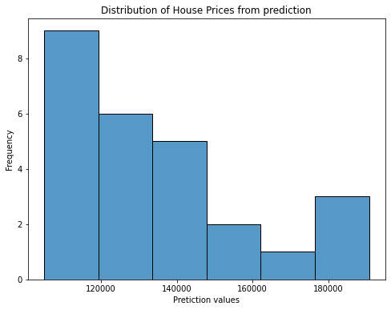

```python
plt.figure(figsize=(8,6))
sns.histplot(Y_pred)
plt.title("Distribution of House Prices from prediction")
plt.ylabel("Frequency")
plt.xlabel("Pretiction values")
plt.show()
```

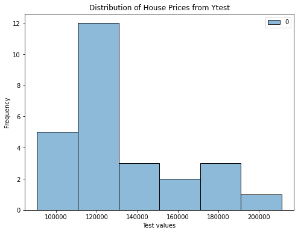

```python
 plt.figure(figsize=(8,6))
 sns.histplot(Ytest)
 plt.title("Distribution of House Prices from Ytest")
 plt.ylabel("Frequency")
 plt.xlabel("Test values")
 plt.show()
```

```python
## custom decision tree regression model
r2_score(Ytest, regressor.predict(Xtest))
```

```
0.8102522362485989
```

Rounding off the error

```python
### using sklearn model finding r2 score
r2_score(Ytest, regr.predict(Xtest))
```

```
0.8102522362485989
```

The r2score for Assignment 3 was 84 % and here it is 81 %.

The custom model gives same accuracy as the sklearn fit model with 81% r2 score.

This R2 value shows by what percentage the independent variables in the model are able to explain the variation in the house prices.

## d) Do you see any overfitting? How to overcome the overfitting issues?

Using hyperparameters tunning we can avoid overfitting issue. For instance if the value of max_depth is increased to match the values of number of features it can result in more training accuracy. This is low bias and high variance. By limiting the height of binary tree it will generate tree with increased prediction error to avoid overfitting.

In general wwo approaches for avoiding overfitting are distinguished:

1. pre-pruning (generating a tree with fewer branches than would otherwise be the case
2. post-pruning (generating a tree in full and then removing parts of it).

# **Question2**

Classify homework 4 dataset with the decision tree model

a) Fit the decision tree model with RINGS as a response variable. How is the model performance? How do you interpret the model?

b) Fit the decision tree with the custom response variable which you created in homework 4. Compare the model performance against logistic regression model (Only performance metrics are fine. Do not need to repeat the code)? Do you find any interesting insights on decision tree model? Which model do you choose for this dataset?

c) If you would like to improve the performance of the decision tree using this model, what steps do you recommend?

d) What hyperparameters can you use for model optimization in the decision tree?

e) How do you control the depth of the decision tree in your custom model?

## Input Data

- SEX = M (male), F (female), I (infant)
- LENGTH = Longest shell length in mm
- DIAM = Diameter perpendicular to length in mm
- HEIGHT = Height perpendicular to length and diameter in mm
- WHOLE = Whole weight of abalone in grams
- SHUCK = Shucked weight of meat in grams
- VISCERA = Viscera weight in grams
- SHELL = Shell weight after drying in grams
- RINGS = Age (+1.5 gives the age in years)
- CLASS = Age classification from 1 to 6 (A1= youngest,..., A6=oldest)

```python
df2 = pd.read_csv('/content/drive/MyDrive/SemesterThree/Stats7300/Assignment4/abalone.data',header=None)
```

```python
df2.tail()
```

|  | 0 | 1 | 2 | 3 | 4 | 5 | 6 | 7 | 8 |
| --- | --- | --- | --- | --- | --- | --- | --- | --- | --- |
| 4172 | F | 0.565 | 0.450 | 0.165 | 0.8870 | 0.3700 | 0.2390 | 0.2490 | 11 |
| 4173 | M | 0.590 | 0.440 | 0.135 | 0.9660 | 0.4390 | 0.2145 | 0.2605 | 10 |
| 4174 | M | 0.600 | 0.475 | 0.205 | 1.1760 | 0.5255 | 0.2875 | 0.3080 | 9 |
| 4175 | F | 0.625 | 0.485 | 0.150 | 1.0945 | 0.5310 | 0.2610 | 0.2960 | 10 |
| 4176 | M | 0.710 | 0.555 | 0.195 | 1.9485 | 0.9455 | 0.3765 | 0.4950 | 12 |

```python
df2.columns = ['SEX','LENGTH','DIAM','HEIGHT','WHOLE','SHUCK','VISCERA','SHELL','RINGS']
```

```python
df2
```

|  | SEX | LENGTH | DIAM | HEIGHT | WHOLE | SHUCK | VISCERA | SHELL | RINGS |
| --- | --- | --- | --- | --- | --- | --- | --- | --- | --- |
| 0 | M | 0.455 | 0.365 | 0.095 | 0.5140 | 0.2245 | 0.1010 | 0.1500 | 15 |
| 1 | M | 0.350 | 0.265 | 0.090 | 0.2255 | 0.0995 | 0.0485 | 0.0700 | 7 |
| 2 | F | 0.530 | 0.420 | 0.135 | 0.6770 | 0.2565 | 0.1415 | 0.2100 | 9 |
| 3 | M | 0.440 | 0.365 | 0.125 | 0.5160 | 0.2155 | 0.1140 | 0.1550 | 10 |
| 4 | I | 0.330 | 0.255 | 0.080 | 0.2050 | 0.0895 | 0.0395 | 0.0550 | 7 |
| ... | ... | ... | ... | ... | ... | ... | ... | ... | ... |
| 4172 | F | 0.565 | 0.450 | 0.165 | 0.8870 | 0.3700 | 0.2390 | 0.2490 | 11 |
| 4173 | M | 0.590 | 0.440 | 0.135 | 0.9660 | 0.4390 | 0.2145 | 0.2605 | 10 |
| 4174 | M | 0.600 | 0.475 | 0.205 | 1.1760 | 0.5255 | 0.2875 | 0.3080 | 9 |
| 4175 | F | 0.625 | 0.485 | 0.150 | 1.0945 | 0.5310 | 0.2610 | 0.2960 | 10 |
| 4176 | M | 0.710 | 0.555 | 0.195 | 1.9485 | 0.9455 | 0.3765 | 0.4950 | 12 |

4177 rows × 9 columns

```python
df2.isna().sum()
```

```
SEX        0
LENGTH     0
DIAM       0
HEIGHT     0
WHOLE      0
SHUCK      0
VISCERA    0
SHELL      0
RINGS      0
dtype: int64
```

```python
df2.info()
```

```
<class 'pandas.core.frame.DataFrame'>
RangeIndex: 4177 entries, 0 to 4176
Data columns (total 9 columns):
 #   Column   Non-Null Count  Dtype
---  ------   --------------  -----
 0   SEX      4177 non-null   object
 1   LENGTH   4177 non-null   float64
 2   DIAM     4177 non-null   float64
 3   HEIGHT   4177 non-null   float64
 4   WHOLE    4177 non-null   float64
 5   SHUCK    4177 non-null   float64
 6   VISCERA  4177 non-null   float64
 7   SHELL    4177 non-null   float64
 8   RINGS    4177 non-null   int64
dtypes: float64(7), int64(1), object(1)
memory usage: 293.8+ KB
```

```python
## 0 height values to be removed
df2 = df2[df2.HEIGHT > 0]
```

```python
df2.corr()
```

|  | LENGTH | DIAM | HEIGHT | WHOLE | SHUCK | VISCERA | SHELL | RINGS |
| --- | --- | --- | --- | --- | --- | --- | --- | --- |
| LENGTH | 1.000000 | 0.986802 | 0.828108 | 0.925217 | 0.897859 | 0.902960 | 0.898419 | 0.556464 |
| DIAM | 0.986802 | 1.000000 | 0.834298 | 0.925414 | 0.893108 | 0.899672 | 0.906084 | 0.574418 |
| HEIGHT | 0.828108 | 0.834298 | 1.000000 | 0.819886 | 0.775621 | 0.798908 | 0.819596 | 0.557625 |
| WHOLE | 0.925217 | 0.925414 | 0.819886 | 1.000000 | 0.969389 | 0.966354 | 0.955924 | 0.540151 |
| SHUCK | 0.897859 | 0.893108 | 0.775621 | 0.969389 | 1.000000 | 0.931924 | 0.883129 | 0.420597 |
| VISCERA | 0.902960 | 0.899672 | 0.798908 | 0.966354 | 0.931924 | 1.000000 | 0.908186 | 0.503562 |
| SHELL | 0.898419 | 0.906084 | 0.819596 | 0.955924 | 0.883129 | 0.908186 | 1.000000 | 0.627928 |
| RINGS | 0.556464 | 0.574418 | 0.557625 | 0.540151 | 0.420597 | 0.503562 | 0.627928 | 1.000000 |

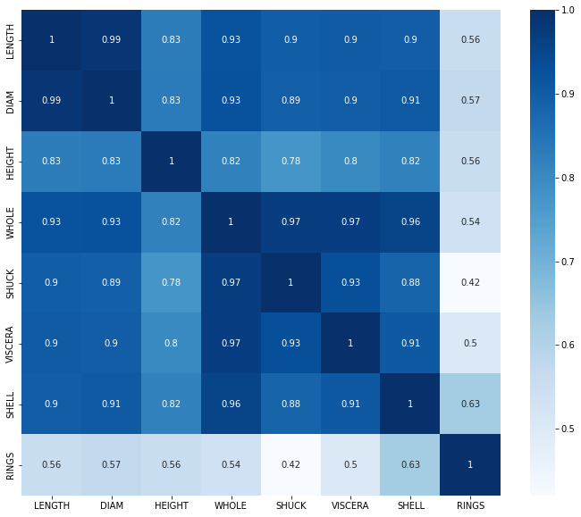

```python
plt.figure(figsize=(12,10))
sns.heatmap(df2.corr(), annot=True, cmap='Blues')
plt.show()
```

Features are highly correlated; length and diameter, length and height, weight. This can lead to multicollinearity.

## Converting categorical columns into numeric

#### Sex categorical variable of object data type need to be converted to numerical value. So that it is converted to Machine Learning model acceptable format.

- LableEncoding
- OneHotEncoding
- Mapping function

```python
df2['SEX'].value_counts()
```

```
M    1528
I    1340
F    1307
Name: SEX, dtype: int64
```

```python
values = {'M':0, 'F':1, 'I':2}
df2['SEX'] = df2['SEX'].map(values)
```

```python
df2.head()
```

|  | SEX | LENGTH | DIAM | HEIGHT | WHOLE | SHUCK | VISCERA | SHELL | RINGS |
| --- | --- | --- | --- | --- | --- | --- | --- | --- | --- |
| 0 | 0 | 0.455 | 0.365 | 0.095 | 0.5140 | 0.2245 | 0.1010 | 0.150 | 15 |
| 1 | 0 | 0.350 | 0.265 | 0.090 | 0.2255 | 0.0995 | 0.0485 | 0.070 | 7 |
| 2 | 1 | 0.530 | 0.420 | 0.135 | 0.6770 | 0.2565 | 0.1415 | 0.210 | 9 |
| 3 | 0 | 0.440 | 0.365 | 0.125 | 0.5160 | 0.2155 | 0.1140 | 0.155 | 10 |
| 4 | 2 | 0.330 | 0.255 | 0.080 | 0.2050 | 0.0895 | 0.0395 | 0.055 | 7 |

```python
df2.describe()
```

|  | SEX | LENGTH | DIAM | HEIGHT | WHOLE | SHUCK | VISCERA | SHELL | RINGS |
| --- | --- | --- | --- | --- | --- | --- | --- | --- | --- |
| count | 4175.000000 | 4175.000000 | 4175.00000 | 4175.000000 | 4175.000000 | 4175.000000 | 4175.000000 | 4175.000000 | 4175.000000 |
| mean | 0.954970 | 0.524065 | 0.40794 | 0.139583 | 0.829005 | 0.359476 | 0.180653 | 0.238834 | 9.935090 |
| std | 0.827697 | 0.120069 | 0.09922 | 0.041725 | 0.490349 | 0.221954 | 0.109605 | 0.139212 | 3.224227 |
| min | 0.000000 | 0.075000 | 0.05500 | 0.010000 | 0.002000 | 0.001000 | 0.000500 | 0.001500 | 1.000000 |
| 25% | 0.000000 | 0.450000 | 0.35000 | 0.115000 | 0.442250 | 0.186250 | 0.093500 | 0.130000 | 8.000000 |
| 50% | 1.000000 | 0.545000 | 0.42500 | 0.140000 | 0.800000 | 0.336000 | 0.171000 | 0.234000 | 9.000000 |
| 75% | 2.000000 | 0.615000 | 0.48000 | 0.165000 | 1.153500 | 0.502000 | 0.253000 | 0.328750 | 11.000000 |
| max | 2.000000 | 0.815000 | 0.65000 | 1.130000 | 2.825500 | 1.488000 | 0.760000 | 1.005000 | 29.000000 |

## a) Fit the decision tree model with RINGS as a response variable. How is the model performance? How do you interpret the model?

```python
y2=df2["RINGS"].values.reshape(-1,1)
df2["RINGS"].value_counts(sort=True)

### 30 class labels
```

#### Idea/Intuition

```python
df2["RINGS"].min()
```

```
1
```

```python
df2["RINGS"].max()
```

```
29
```

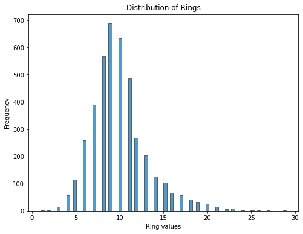

```python
plt.figure(figsize=(8,6))
sns.histplot(df2["RINGS"])
plt.title("Distribution of Rings")
plt.ylabel("Frequency")
plt.xlabel("Ring values")
plt.show()
```

As the rings are continuous values we can use Regression to predict RINGS

```python
x2 = df2.iloc[:,:-1].values
x2[:]
```

```
array([[0.    , 0.455 , 0.365 , ..., 0.2245, 0.101 , 0.15  ],
       [0.    , 0.35  , 0.265 , ..., 0.0995, 0.0485, 0.07  ],
       [1.    , 0.53  , 0.42  , ..., 0.2565, 0.1415, 0.21  ],
       ...,
       [0.    , 0.6   , 0.475 , ..., 0.5255, 0.2875, 0.308 ],
       [1.    , 0.625 , 0.485 , ..., 0.531 , 0.261 , 0.296 ],
       [0.    , 0.71  , 0.555 , ..., 0.9455, 0.3765, 0.495 ]])
```

```python
x_train, x_test, y_train, y_test = train_test_split(x2, y2, test_size=.2, random_state=41)
```

```python
rings_model = custom_DecisionTreeRegressor(min_samples_split=3, max_depth=3)
rings_model.fit(x_train,y_train)
rings_model.print_tree()
```

```
X_7 <= 0.1785 ? 2.8982074023651068
 left:X_7 <= 0.0585 ? 1.2052218683676212
  left:X_1 <= 0.25 ? 0.7673609693402217
    left:X_6 <= 0.011 ? 0.19869303015323825
        left:3.98
        right:4.885714285714286
    right:X_2 <= 0.22 ? 0.21102608408407653
        left:5.776595744680851
        right:6.700854700854701
  right:X_0 <= 1.0 ? 0.5054705448137167
    left:X_5 <= 0.2635 ? 0.30879871569729067
        left:9.435331230283913
        right:8.05
    right:X_7 <= 0.1195 ? 0.37232002666232544
        left:7.1880877742946705
        right:8.421940928270041
 right:X_7 <= 0.4095 ? 0.9142279114583136
  left:X_7 <= 0.2895 ? 0.3020469297033914
    left:X_5 <= 0.306 ? 0.6558828569071053
        left:11.491467576791809
        right:9.738931297709923
    right:X_5 <= 0.422 ? 1.507204782231657
        left:13.718562874251496
        right:10.739635157545605
  right:X_5 <= 0.55 ? 1.8230677092197247
    left:X_1 <= 0.55 ? 1.4038638741480156
        left:23.5
        right:15.505747126436782
    right:X_7 <= 0.5675 ? 1.3321523422583503
        left:11.951965065502183
        right:14.872727272727273
```

As per the print tree we are getting feature values at non leaf nodes with conditions.

And leaf nodes corresponding to mean predicted output.

The most important feature is X_7 that is shell, with highest information gain. Followed by other features like X_5, x_1.

#### Visualizing tree

```python
## Using sklearn library to perform regression
sklearn_model = DecisionTreeRegressor(max_depth=3)
model = sklearn_model.fit(x_train, y_train)
r = tree.export_text(sklearn_model)
print(r)
```

```
|--- feature_7 <= 0.18
|   |--- feature_7 <= 0.06
|   |   |--- feature_1 <= 0.25
|   |   |   |--- value: [4.35]
|   |   |--- feature_1 >  0.25
|   |   |   |--- value: [6.29]
|   |--- feature_7 >  0.06
|   |   |--- feature_0 <= 1.50
|   |   |   |--- value: [9.16]
|   |   |--- feature_0 >  1.50
|   |   |   |--- value: [7.71]
|--- feature_7 >  0.18
|   |--- feature_7 <= 0.41
|   |   |--- feature_7 <= 0.29
|   |   |   |--- value: [10.28]
|   |   |--- feature_7 >  0.29
|   |   |   |--- value: [11.39]
|   |--- feature_7 >  0.41
|   |   |--- feature_5 <= 0.55
|   |   |   |--- value: [15.69]
|   |   |--- feature_5 >  0.55
|   |   |   |--- value: [12.52]
```

```python
from dtreeviz.trees import dtreeviz # remember to load the package

viz = dtreeviz(sklearn_model, x_train, y_train,
                target_name="target",
                feature_names=df2.iloc[:,:-1].columns,
                   class_names=df2['RINGS'])
viz
```

```
Output hidden; open in https://colab.research.google.com to view.
```

```python
x_test
```

```
array([[1.    , 0.645 , 0.51  , ..., 0.5815, 0.276 , 0.315 ],
       [1.    , 0.37  , 0.29  , ..., 0.111 , 0.057 , 0.075 ],
       [0.    , 0.715 , 0.535 , ..., 0.889 , 0.313 , 0.42  ],
       ...,
       [2.    , 0.42  , 0.315 , ..., 0.157 , 0.0795, 0.09  ],
       [0.    , 0.37  , 0.28  , ..., 0.0905, 0.0585, 0.075 ],
       [1.    , 0.66  , 0.525 , ..., 0.4975, 0.319 , 0.394 ]])
```

```python
y_pred = rings_model.predict(x_test)
```

```python
r2_score(y_test, y_pred)
```

```
0.4636771365762127
```

Low accuracy as there are 30 continuous values which makes model complex.

Let's calculate score for sklearn decision tree model.

```python
r2_score(y_test, sklearn_model.predict(x_test))
```

```
0.38532708089938705
```

Thus the model performance of custom tree model is better than that of sklearn model.

1. Custom Decision Tree for rings prediction - r2score = 46%
2. Sklearn Decision Tree for rings prediction - r2score = 38%

Model performance is better than sklearn but overall not good. This is beacuse the values of rings eventhough continuous numeric they represent categories of age values. Hence it is useful to see it as classification problem and use decision tree classifier.

## b) Fit the decision tree with the custom response variable which you created in homework 4. Compare the model performance against logistic regression model (Only performance metrics are fine. Do not need to repeat the code)? Do you find any interesting insights on decision tree model? Which model do you choose for this dataset?

#### Adding Class labels

```python
df2['AGE'] = df2['RINGS']+1.5
```

```python
df2['AGE'].value_counts()
```

```python
df2['AGE'].describe()
```

```python
conditions = [
    (df2['AGE'] < 7),
    (df2['AGE'] >= 7) & (df2['AGE'] < 14),
    (df2['AGE'] >= 14) & (df2['AGE'] < 21),
    (df2['AGE'] >= 21) & (df2['AGE'] < 28),
    (df2['AGE'] >= 28) & (df2['AGE'] < 35),
    (df2['AGE'] >= 35)
]

values = [1,2,3,4,5,6]

df2['CLASS'] = np.select(conditions, values)
```

```python
df2["CLASS"].value_counts()
```

```
2    3291
3     631
1     189
4      59
5       3
Name: CLASS, dtype: int64
```

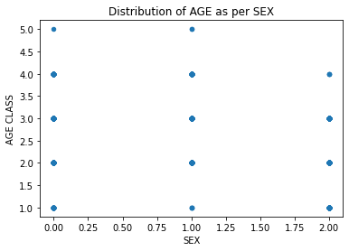

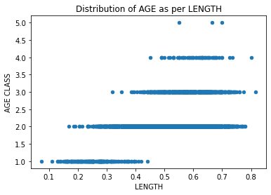

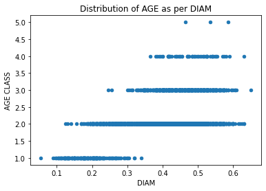

[figure not shown]

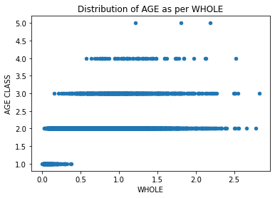

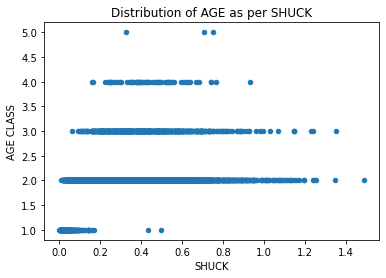

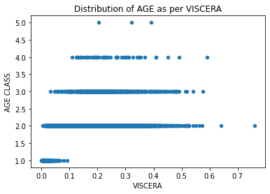

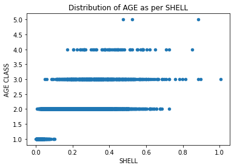

```python
features = ["SEX",	"LENGTH",	"DIAM",	"HEIGHT",	"WHOLE",	"SHUCK", "VISCERA", "SHELL"]
for i in range(0,8):
  df2.plot(kind = 'scatter', x=features[i], y='CLASS')
  plt.xlabel(features[i])
  plt.ylabel('AGE CLASS')
  plt.title('Distribution of AGE as per '+features[i])
  plt.show()
```

```python
df2 = df2[df2.HEIGHT < 0.4]
```

```python
df2.shape
```

```
(4173, 11)
```

#### Idea/Intuition

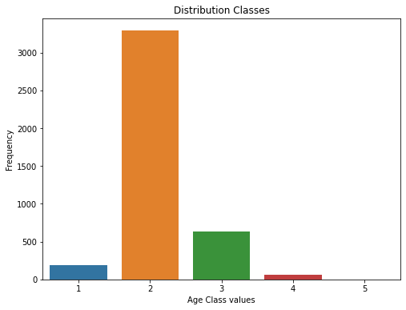

```python
plt.figure(figsize=(8,6))
sns.countplot(df2["CLASS"])
plt.title("Distribution Classes")
plt.ylabel("Frequency")
plt.xlabel("Age Class values")
plt.show()
```

#### Define features and labels

```python
df2
```

|  | SEX | LENGTH | DIAM | HEIGHT | WHOLE | SHUCK | VISCERA | SHELL | RINGS | AGE | CLASS |
| --- | --- | --- | --- | --- | --- | --- | --- | --- | --- | --- | --- |
| 0 | 0 | 0.455 | 0.365 | 0.095 | 0.5140 | 0.2245 | 0.1010 | 0.1500 | 15 | 16.5 | 3 |
| 1 | 0 | 0.350 | 0.265 | 0.090 | 0.2255 | 0.0995 | 0.0485 | 0.0700 | 7 | 8.5 | 2 |
| 2 | 1 | 0.530 | 0.420 | 0.135 | 0.6770 | 0.2565 | 0.1415 | 0.2100 | 9 | 10.5 | 2 |
| 3 | 0 | 0.440 | 0.365 | 0.125 | 0.5160 | 0.2155 | 0.1140 | 0.1550 | 10 | 11.5 | 2 |
| 4 | 2 | 0.330 | 0.255 | 0.080 | 0.2050 | 0.0895 | 0.0395 | 0.0550 | 7 | 8.5 | 2 |
| ... | ... | ... | ... | ... | ... | ... | ... | ... | ... | ... | ... |
| 4172 | 1 | 0.565 | 0.450 | 0.165 | 0.8870 | 0.3700 | 0.2390 | 0.2490 | 11 | 12.5 | 2 |
| 4173 | 0 | 0.590 | 0.440 | 0.135 | 0.9660 | 0.4390 | 0.2145 | 0.2605 | 10 | 11.5 | 2 |
| 4174 | 0 | 0.600 | 0.475 | 0.205 | 1.1760 | 0.5255 | 0.2875 | 0.3080 | 9 | 10.5 | 2 |
| 4175 | 1 | 0.625 | 0.485 | 0.150 | 1.0945 | 0.5310 | 0.2610 | 0.2960 | 10 | 11.5 | 2 |
| 4176 | 0 | 0.710 | 0.555 | 0.195 | 1.9485 | 0.9455 | 0.3765 | 0.4950 | 12 | 13.5 | 2 |

4173 rows × 11 columns

```python
#Data contains 8 feature variables and 1 target variable AGE CLASS
# Define features and labels
```

```python
Y2=df2["CLASS"].values.reshape(-1,1)
```

```python
df2_final = df2[["SEX",	"LENGTH",	"DIAM",	"HEIGHT",	"WHOLE",	"SHUCK", "VISCERA", "SHELL"]]
X2 = df2_final.values
```

#### Spliting dataset

```python
X_train, X_test, Y_train, Y_test = train_test_split(X2, Y2, test_size=0.2, random_state=41)
```

```python
classifier = custom_DecisionTreeClassifier(min_samples_split=3, max_depth=3)
classifier.fit(X_train,Y_train)
classifier.print_tree()
```

```
X_6 <= 0.0245 ? 0.03410860008971184
 left:X_7 <= 0.023 ? 0.07938814756095758
  left:X_6 <= 0.011 ? 0.017668107688683876
    left:X_3 <= 0.05 ? 0.004340277777777832
        left:1.0
        right:1.0
    right:X_5 <= 0.023 ? 0.08087165359892629
        left:1.0
        right:1.0
  right:X_5 <= 0.0395 ? 0.03958944281524923
    left:X_6 <= 0.023 ? 0.07621868246217872
        left:2.0
        right:1.0
    right:X_5 <= 0.046 ? 0.12583110669235065
        left:1.0
        right:2.0
 right:X_7 <= 0.3145 ? 0.018648238817229768
  left:X_7 <= 0.1895 ? 0.006580768098548184
    left:X_7 <= 0.05 ? 0.006804868541560677
        left:2.0
        right:2.0
    right:X_5 <= 0.314 ? 0.026703221283446932
        left:2.0
        right:2.0
  right:X_5 <= 0.487 ? 0.03471034524672789
    left:X_3 <= 0.185 ? 0.02820011247798293
        left:2.0
        right:3.0
    right:X_7 <= 0.4435 ? 0.03287433129935968
        left:2.0
        right:2.0
```

```python
Y_pred = classifier.predict(X_test)
accuracy_score(Y_test, Y_pred)
```

```
0.7976047904191617
```

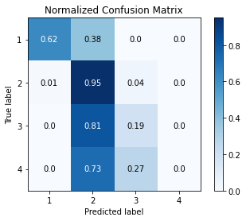

```python
skplt.metrics.plot_confusion_matrix(Y_test, Y_pred, normalize=True)
```

#### Sklearn model

```python
# Fit the classifier with default hyper-parameters
clf = DecisionTreeClassifier(max_depth=3)
model = clf.fit(X_train, Y_train)
text_representation = tree.export_text(clf)
print(text_representation)
```

```
|--- feature_6 <= 0.02
|   |--- feature_7 <= 0.02
|   |   |--- feature_6 <= 0.01
|   |   |   |--- class: 1
|   |   |--- feature_6 >  0.01
|   |   |   |--- class: 1
|   |--- feature_7 >  0.02
|   |   |--- feature_5 <= 0.04
|   |   |   |--- class: 2
|   |   |--- feature_5 >  0.04
|   |   |   |--- class: 1
|--- feature_6 >  0.02
|   |--- feature_7 <= 0.31
|   |   |--- feature_7 <= 0.19
|   |   |   |--- class: 2
|   |   |--- feature_7 >  0.19
|   |   |   |--- class: 2
|   |--- feature_7 >  0.31
|   |   |--- feature_5 <= 0.49
|   |   |   |--- class: 3
|   |   |--- feature_5 >  0.49
|   |   |   |--- class: 2
```

```python
import graphviz
# DOT data
dot_data = tree.export_graphviz(clf,
                                feature_names = df2.iloc[:,:-3].columns,
                                class_names = str(df2["CLASS"].values))
graph = graphviz.Source(dot_data, format="png")
graph
```

[figure not shown]

```python
Y_pred = clf.predict(X_test)
accuracy_score(Y_test, Y_pred)
```

```
0.8023952095808383
```

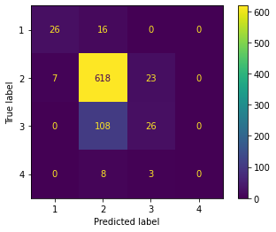

```python
plot_confusion_matrix(clf, X_test, Y_test)
plt.show()
```

Also accuracy score is improved in comparison to Logistic regression model from Homework 4.

## c) If you would like to improve the performance of the decision tree using this model, what steps do you recommend?

1. Hyperparameter tuning using GridsearchCV
2. Creating less number of target classes to reduce complexity in classification
3. Add more data to train model and avoid overfitting
4. EDA - removing null values and outliers
5. Build shallow decision trees with max_depth value not more than 3 and control depth of decision tree

## d) What hyperparameters can you use for model optimization in the decision tree?

1. min_sample_splits
2. max_depth
3. cross validation number - 5 fold , 8 fold
4. random state - to simulate the same tree in future
5. criterion - gini index, entropy

## e) How do you control the depth of the decision tree in your custom model?

#### Controlling depth of recursion tree is important as it will avoid encountering overfitting issue.

We can use GridsearchCV sklearn library to pass different values of hyper paramater maximum depth. Once we tune model with the optimum max depth we can use same hyper parameter value for test set.

For this we can divide the dataset in training, validation and test sets.

1. Training set is used to fit data.
2. Validation set is used to get validation accuracy and tune hyper parameter called max depth.
3. Test set will be giving the better results due to controlling depth using multifold gridsearchCV tuning method.